### Please see the Jupyter Notebook file for clear fomula/tables/figures. The .pdf cannot fully show them.

```python
import numpy as np
import pandas as pd
import matplotlib.pyplot as plt

plt.style.use('fivethirtyeight')
```

# Task 1

## Part 1.1

Three schemes **Euler-Maruyama scheme**, **Milstein scheme** and **closed form solution** list increasing by accuracy of simulation.

Under the risk-neutral case, we would apply the $\mathbb{Q}$ measure.

- Euler-Maruyama: $$S_{t+\delta t} = S_t \bigg(1+r \delta t + \sigma\phi \sqrt{\delta t} \bigg)$$
- Milstein Scheme: $$S_{t+\delta t} = S_t \bigg(1+r \delta t + \sigma\phi \sqrt{\delta t} + \frac{1}{2}\sigma^2 (\phi^2-1)\delta t\bigg)$$
- Close Form Solution: $$S_{t+\delta t} = S_t e^{(r- \frac{1}{2}\sigma^2)\delta t + \sigma \phi \sqrt{\delta t}}$$

, where $\phi$ represents the standard normal distribtuion, N(0,1).

In the following table, the Column-Name: 'EM','Milstein','Exact', each represents the result of a scheme.

- `EM` - Euler-Maruyama
- `Milstein` - Milstein Scheme
- `Exact` - Close-Form Soulution

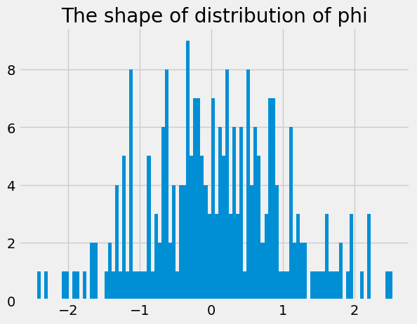

```python
S0 = 100
T = 1
periods = T*252 # assume dt is in daily form
dt = T / periods
sigma = 0.2
r = 0.05

# set the seed of randomness
np.random.seed(1)
phi = np.random.randn(periods)

plt.hist(phi, bins = 100)
plt.title('The shape of distribution of phi')
plt.show()

task1_table = np.zeros([len(phi), 4])
task1_table[0] = S0
task1_table[:,0] = phi
task1_table = pd.DataFrame(task1_table, columns=['phi','EM','Milstein','Exact'])
```

```python
for i in range(len(task1_table)-1):

    # Euler-Maruyama
    task1_table.EM[i+1] = task1_table.EM[i] * (1 + r * dt + sigma * task1_table.phi[i] * np.sqrt(dt))

    # Milstein
    task1_table.Milstein[i+1] = task1_table.Milstein[i] * \
        (1 + r * dt + sigma * task1_table.phi[i] * np.sqrt(dt) + \
         0.5 * sigma**2 * (task1_table.phi[i]**2 - 1) * dt)

    # Close Form Soluation
    task1_table.Exact[i+1] = task1_table.Exact[i] * \
        np.exp( (r - 0.5 * sigma**2) * dt + sigma * task1_table.phi[i] * np.sqrt(dt) )
```

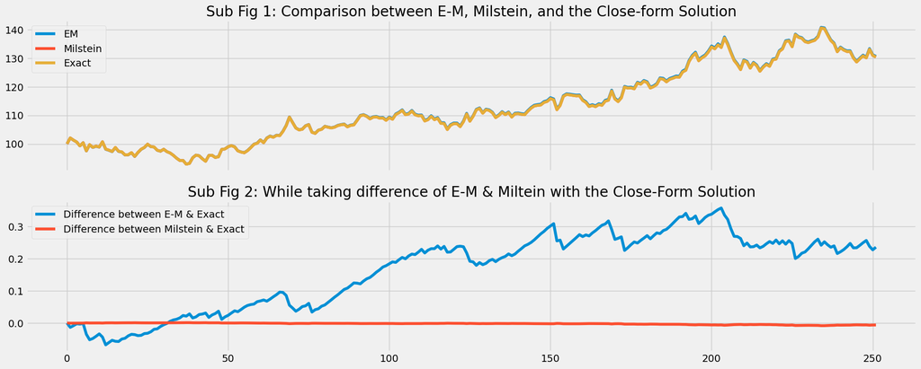

```python
figure, axes = plt.subplots(2,1, figsize=(20,8), sharex=True)
axes[0].plot(task1_table[['EM', 'Milstein', 'Exact']], label=['EM', 'Milstein', 'Exact'])
axes[0].legend()
axes[0].set_title('Sub Fig 1: Comparison between E-M, Milstein, and the Close-form Solution')

axes[1].plot(task1_table.EM - task1_table.Exact, label = 'Difference between E-M & Exact')
axes[1].plot(task1_table.Milstein - task1_table.Exact, label = 'Difference between Milstein & Exact')
axes[1].legend()
axes[1].set_title('Sub Fig 2: While taking difference of E-M & Miltein with the Close-Form Solution')
plt.show()
```

The column `Exact` stands for the close-form solution.

From the Sub-Figure 1 above, we can clear find that three schemes shows similar movement across a year of time (252 trading days, indicated by `dt`).

From the Sub-Figure 2 above, we can find that the Milstein result is more close the the Close-Form solution, as the red curve is close to '0'. Whereas, the Euler-Maruyama result, showing by the blue cuve of Sub-Fig2, variates.

The reason is that Miltein Scheme as the error term $O(\delta t)$, which is smaller than the E-M Scheme's $O(\sqrt{\delta t})$, as $\delta t \to 0$.

## Part 1.2

Under the risk-neutral framework, we assume the asset is going to earn, on average, the risk-free interest rate. Hence, the option value at time $t$ would simply be the discounted value of the expected payoff. Under the $\mathbb{Q}$-measure,

$$V(S,t) = e^{-r(T-t)}\mathbb{E}^{\mathbb{Q}}[Payoff]$$

**For the Asian Call Option**

An Asian option is an option where the payoff depends on the average price of the underlying asset over a certain period of time. Averaging can be either be Arithmetic or Geometric. Two types of Asian options:

- Fixed strike: averaging price is used in place of underlying price.
- Float strike: averaging price is used in place of strike.

We'll now price a fixed strike arthmetic average option using Monte Carlo simulation.

**The payoff of the options is given by** (under the risk-neutral $\mathbb{Q}$ measure),

- For Fixed-Strike Asian Options, $$C_t = e^{-r(T-t)}\mathbb{E}(max(0,S_{Avg} - K)$$

$$P_t = e^{-r(T-t)}\mathbb{E}(max(0,K - S_{Avg})$$

- For Float-Strike Asian Options, $$C_t = e^{-r(T-t)}\mathbb{E}(max(0,S_T - S_{Avg})$$

$$P_t = e^{-r(T-t)}\mathbb{E}(max(0,S_{Avg} - S_T)$$

- For Continuous Sampling $$A = \frac{1}{t}\int_0^t S(u) du$$
- For Discrete Sampling $$A = \frac{1}{t} \sum_{i=0}^t S(i)$$
- Geometric Average

$$ G = \big( \prod_{i=0}^t S(i) \big)^{1/t} $$$$ G = exp\{\frac{1}{t}\sum_{i=0}^t logS_i\} $$

[figure not shown]

```
The Expire value of continuous and discrete averaging are the Same, with
Continuous Averaging Expire Date Value: 99.06496233209795
Discrete Averaging Expire Date Value: 99.06496233209795
```

```python
# define simulation function, which is used for the risk-neutral Q-measurement
def simulate_path(S0, mu, sigma, T, periods, n_sims):

    # set the seed of randomness
    np.random.seed(0)

    # define dt
    periods = T*periods
    dt = T/periods                # length of time interval

    # create a new table
    task1_table2 = []
    for i in range(3):
        # simulate 'n' asset price path with 't' timesteps
        S = np.zeros((periods,n_sims))
        S[0] = S0
        task1_table2.append(S)

    for i in range(0, periods-1):
        # initialise the randomness 'phi' ~ N(0,1), period by period
        phi = np.random.standard_normal(n_sims)
        # E-M  ->  task1_table2[0]
        task1_table2[0][i+1] = task1_table2[0][i] * (1 + mu * dt + sigma * phi * np.sqrt(dt))
        # Milstein  ->  task1_table2[1]
        task1_table2[1][i+1] = task1_table2[1][i] * \
            (1 + mu * dt + sigma * phi * np.sqrt(dt) + \
            0.5 * sigma**2 * (phi**2 - 1) * dt)
        # Exact  ->  task1_table2[2]
        task1_table2[2][i+1] = task1_table2[2][i] * \
        np.exp( (r - 0.5 * sigma**2) * dt + sigma * phi * np.sqrt(dt) )

    return task1_table2

# original one
def cum_ave(Series, steps=periods):
    cum = int(len(Series)/steps)
    mean_series = pd.Series(np.zeros(len(Series)))
    for i in range(steps):
        mean_series[i*cum:(i+1)*cum]=np.mean(Series[:(i+1)*cum])
    mean_series = mean_series.replace(to_replace=0, method='ffill')
    return mean_series

def geo_ave(Series):
    periods = Series.shape[0]
    return np.exp(1/periods* np.sum( np.log(Series) ))
########################
E = 100
T = 1
n_sim = 10_000 # here, we simulate 10k times
S_task1 = simulate_path(S0, r, sigma, T, periods, n_sim)

temp = S_task1[0][:,0]
plt.figure(figsize=[8,6])
plt.plot(temp, label='E-M Stock Price Movement')
plt.plot(cum_ave(temp,4), label='Discrete Sampling with 12 periods', color = 'g')
plt.plot(cum_ave(temp), label='Continuous Sampling')
plt.title('Comparison between Continuous and Discrete Sampling')
plt.legend()
plt.xlabel('Number of Days in One Period')
plt.show()
print(f'The Expire value of continuous and discrete averaging are the Same, with')
print(f'Continuous Averaging Expire Date Value: {cum_ave(temp).iloc[-1]}')
print(f'Discrete Averaging Expire Date Value: {cum_ave(temp,4).iloc[-1]}')
```

```python
E = 100
T = 1
n_sim = 10_000 # here, we simulate 10k times

S_task1 = simulate_path(S0, r, sigma, T, periods, n_sim)

# calculate the arithmetic mean
S_ave = []
S_geo_ave = []
for i in range(3):
    S_ave.append(S_task1[i].mean(axis=0))
    S_geo_ave.append(pd.DataFrame(S_task1[i]).apply(geo_ave))

# create an empty table for presenting the result
col_name = ['Default', 'Fixed_Strike', 'Floating_Strike', 'Discrete_Sampling', \
            'Continuous_Sampling', 'Arithmetic_Ave', 'Geometric_Ave']
task1_pre = pd.DataFrame(np.zeros([6,7]),
                        columns=col_name)
task1_pre.index = [np.array(['EM', 'EM', 'Milstein', 'Milstein', 'Exact', 'Exact']),\
                 np.array(['Asian_Call', 'Asian_Put']*3)]

# calculate the default type: (1)Fixed Strike (2)Continuous (3)Arithmetric Mean
# we calculate the discrete & continuous average first. `S_task1` is now 3-dimensional
# ,with the first dimension be 'EM', 'Milstein', and 'Exact'
# , and the other two dimensions are periods * n_sims
for i,j in enumerate(['EM', 'Milstein', 'Exact']):
    # Fixed Strike: have a fixed strike value and the average used is the asset price
    task1_pre.loc[(j,'Asian_Call'),'Default'] = np.exp(-r*T) * np.mean(np.maximum(0, S_ave[i] - E) )
    task1_pre.loc[(j,'Asian_Put'),'Default'] = np.exp(-r*T) * np.mean(np.maximum(0, E - S_ave[i]) )
    task1_pre.loc[(j,'Asian_Call'),'Fixed_Strike'] = task1_pre.loc[(j,'Asian_Call'),'Default']
    task1_pre.loc[(j,'Asian_Put'),'Fixed_Strike'] = task1_pre.loc[(j,'Asian_Put'),'Default']

    # Discrete Sampling and Continuous Sampling make no different if the option is European Style
    # , because the average would consider the whole sampling at the Expire Date.
    task1_pre.loc[(j,'Asian_Call'),'Continuous_Sampling'] = task1_pre.loc[(j,'Asian_Call'),'Default']
    task1_pre.loc[(j,'Asian_Put'),'Continuous_Sampling'] = task1_pre.loc[(j,'Asian_Put'),'Default']
    task1_pre.loc[(j,'Asian_Call'),'Discrete_Sampling'] = task1_pre.loc[(j,'Asian_Call'),'Default']
    task1_pre.loc[(j,'Asian_Put'),'Discrete_Sampling'] = task1_pre.loc[(j,'Asian_Put'),'Default']

    # Arithmetic
    task1_pre.loc[(j,'Asian_Call'),'Arithmetic_Ave'] = task1_pre.loc[(j,'Asian_Call'),'Default']
    task1_pre.loc[(j,'Asian_Put'),'Arithmetic_Ave'] = task1_pre.loc[(j,'Asian_Put'),'Default']

    # Float Strike: have a strike equal to the average value of the underlying asset
    task1_pre.loc[(j,'Asian_Call'),'Floating_Strike'] = np.exp(-r*T) * np.mean(np.maximum(0, S_task1[i][-1] - S_ave[i]) )
    task1_pre.loc[(j,'Asian_Put'),'Floating_Strike'] = np.exp(-r*T) * np.mean(np.maximum(0, S_ave[i] - S_task1[0][-1]) )

    # Geometric Averaging
    task1_pre.loc[(j,'Asian_Call'),'Geometric_Ave'] = np.exp(-r*T) * np.mean(np.maximum(0, S_task1[i][-1] - S_geo_ave[i]) )
    task1_pre.loc[(j,'Asian_Put'),'Geometric_Ave'] = np.exp(-r*T) * np.mean(np.maximum(0, S_geo_ave[i] - S_task1[0][-1]) )

task1_pre
```

|  |  | Default | Fixed_Strike | Floating_Strike | Discrete_Sampling | Continuous_Sampling | Arithmetic_Ave | Geometric_Ave |
| --- | --- | --- | --- | --- | --- | --- | --- | --- |
| EM | Asian_Call | 5.742711 | 5.742711 | 5.784830 | 5.742711 | 5.742711 | 5.742711 | 5.990075 |
|  | Asian_Put | 3.201848 | 3.201848 | 3.419059 | 3.201848 | 3.201848 | 3.201848 | 3.294922 |
| Milstein | Asian_Call | 5.740937 | 5.740937 | 5.785385 | 5.740937 | 5.740937 | 5.740937 | 5.990723 |
|  | Asian_Put | 3.201036 | 3.201036 | 3.417985 | 3.201036 | 3.201036 | 3.201036 | 3.293937 |
| Exact | Asian_Call | 5.741937 | 5.741937 | 5.786410 | 5.741937 | 5.741937 | 5.741937 | 5.991824 |
|  | Asian_Put | 3.201776 | 3.201776 | 3.417668 | 3.201776 | 3.201776 | 3.201776 | 3.293569 |

From the Table above, we can find that Milstein Scheme and Exact Solution are nearly the same, the Euler-Maruyama Solution is colse to the other two.

The Values of Asian Option in Fixed-Strike and Floating-Strike are differnt.

Continuous-Sampling and Discrete-Sampling share the same value as we only consider the European style Asian option. The property of path-indepedence of European-Style Asian make their value same, because we have shown the average are same at the expiry date.

Arithmetic and Geometric Average would give different values of asian options. Geometric Averge generally gives a high value for that at-the-money Asian option.

Here below are some comparisons that we write everything into a function and alter some parameters to see how the value of option changes.

```python
def task1_presentation(E, T, n_sim):
    S_task1 = simulate_path(S0, r, sigma, T, periods, n_sim)
    # calculate the arithmetic mean
    S_ave = []
    S_geo_ave = []
    for i in range(3):
        S_ave.append(S_task1[i].mean(axis=0))
        S_geo_ave.append(pd.DataFrame(S_task1[i]).apply(geo_ave))

    # create an empty table for presenting the result
    col_name = ['Default', 'Fixed_Strike', 'Floating_Strike', 'Discrete_Sampling', \
                'Continuous_Sampling', 'Arithmetic_Ave', 'Geometric_Ave']
    task1_pre = pd.DataFrame(np.zeros([6,7]),
                            columns=col_name)
    task1_pre.index = [np.array(['EM', 'EM', 'Milstein', 'Milstein', 'Exact', 'Exact']),\
                     np.array(['Asian_Call', 'Asian_Put']*3)]

    # calculate the default type: (1)Fixed Strike (2)Continuous (3)Arithmetric Mean
    # we calculate the discrete & continuous average first. `S_task1` is now 3-dimensional
    # ,with the first dimension be 'EM', 'Milstein', and 'Exact'
    # , and the other two dimensions are periods * n_sims
    for i,j in enumerate(['EM', 'Milstein', 'Exact']):
        # Fixed Strike: have a fixed strike value and the average used is the asset price
        task1_pre.loc[(j,'Asian_Call'),'Default'] = np.exp(-r*T) * np.mean(np.maximum(0, S_ave[i] - E) )
        task1_pre.loc[(j,'Asian_Put'),'Default'] = np.exp(-r*T) * np.mean(np.maximum(0, E - S_ave[i]) )
        task1_pre.loc[(j,'Asian_Call'),'Fixed_Strike'] = task1_pre.loc[(j,'Asian_Call'),'Default']
        task1_pre.loc[(j,'Asian_Put'),'Fixed_Strike'] = task1_pre.loc[(j,'Asian_Put'),'Default']

        # Discrete Sampling and Continuous Sampling make no different if the option is European Style
        # , because the average would consider the whole sampling at the Expire Date.
        task1_pre.loc[(j,'Asian_Call'),'Continuous_Sampling'] = task1_pre.loc[(j,'Asian_Call'),'Default']
        task1_pre.loc[(j,'Asian_Put'),'Continuous_Sampling'] = task1_pre.loc[(j,'Asian_Put'),'Default']
        task1_pre.loc[(j,'Asian_Call'),'Discrete_Sampling'] = task1_pre.loc[(j,'Asian_Call'),'Default']
        task1_pre.loc[(j,'Asian_Put'),'Discrete_Sampling'] = task1_pre.loc[(j,'Asian_Put'),'Default']

        # Arithmetic
        task1_pre.loc[(j,'Asian_Call'),'Arithmetic_Ave'] = task1_pre.loc[(j,'Asian_Call'),'Default']
        task1_pre.loc[(j,'Asian_Put'),'Arithmetic_Ave'] = task1_pre.loc[(j,'Asian_Put'),'Default']

        # Float Strike: have a strike equal to the average value of the underlying asset
        task1_pre.loc[(j,'Asian_Call'),'Floating_Strike'] = np.exp(-r*T) * np.mean(np.maximum(0, S_task1[i][-1] - S_ave[i]) )
        task1_pre.loc[(j,'Asian_Put'),'Floating_Strike'] = np.exp(-r*T) * np.mean(np.maximum(0, S_ave[i] - S_task1[0][-1]) )

        # Geometric Averaging
        task1_pre.loc[(j,'Asian_Call'),'Geometric_Ave'] = np.exp(-r*T) * np.mean(np.maximum(0, S_task1[i][-1] - S_geo_ave[i]) )
        task1_pre.loc[(j,'Asian_Put'),'Geometric_Ave'] = np.exp(-r*T) * np.mean(np.maximum(0, S_geo_ave[i] - S_task1[0][-1]) )

    return task1_pre


print('Here, we write everything in a function, so that we can easily change parameter E and T, to see how option value changes')
try1 = task1_presentation(E=110, T=2, n_sim=10000)
try1
```

```
Here, we write everything in a function, so that we can easily change parameter E and T, to see how option value changes
```

|  |  | Default | Fixed_Strike | Floating_Strike | Discrete_Sampling | Continuous_Sampling | Arithmetic_Ave | Geometric_Ave |
| --- | --- | --- | --- | --- | --- | --- | --- | --- |
| EM | Asian_Call | 4.401286 | 4.401286 | 9.002469 | 4.401286 | 4.401286 | 4.401286 | 9.452549 |
|  | Asian_Put | 8.669639 | 8.669639 | 4.205349 | 8.669639 | 8.669639 | 8.669639 | 3.983693 |
| Milstein | Asian_Call | 4.401352 | 4.401352 | 8.999772 | 4.401352 | 4.401352 | 4.401352 | 9.450028 |
|  | Asian_Put | 8.671411 | 8.671411 | 4.205480 | 8.671411 | 8.671411 | 8.671411 | 3.983952 |
| Exact | Asian_Call | 4.402765 | 4.402765 | 9.001303 | 4.402765 | 4.402765 | 4.402765 | 9.451722 |
|  | Asian_Put | 8.672333 | 8.672333 | 4.205069 | 8.672333 | 8.672333 | 8.672333 | 3.983452 |

```python
try2 = task1_presentation(E=110, T=1, n_sim=10000)
try2
```

|  |  | Default | Fixed_Strike | Floating_Strike | Discrete_Sampling | Continuous_Sampling | Arithmetic_Ave | Geometric_Ave |
| --- | --- | --- | --- | --- | --- | --- | --- | --- |
| EM | Asian_Call | 1.947390 | 1.947390 | 5.784830 | 1.947390 | 1.947390 | 1.947390 | 5.990075 |
|  | Asian_Put | 8.918821 | 8.918821 | 3.419059 | 8.918821 | 8.918821 | 8.918821 | 3.294922 |
| Milstein | Asian_Call | 1.947471 | 1.947471 | 5.785385 | 1.947471 | 1.947471 | 1.947471 | 5.990723 |
|  | Asian_Put | 8.919865 | 8.919865 | 3.417985 | 8.919865 | 8.919865 | 8.919865 | 3.293937 |
| Exact | Asian_Call | 1.948305 | 1.948305 | 5.786410 | 1.948305 | 1.948305 | 1.948305 | 5.991824 |
|  | Asian_Put | 8.920439 | 8.920439 | 3.417668 | 8.920439 | 8.920439 | 8.920439 | 3.293569 |

```python
try3 = task1_presentation(E=100, T=1, n_sim=10000)
try3
```

|  |  | Default | Fixed_Strike | Floating_Strike | Discrete_Sampling | Continuous_Sampling | Arithmetic_Ave | Geometric_Ave |
| --- | --- | --- | --- | --- | --- | --- | --- | --- |
| EM | Asian_Call | 5.742711 | 5.742711 | 5.784830 | 5.742711 | 5.742711 | 5.742711 | 5.990075 |
|  | Asian_Put | 3.201848 | 3.201848 | 3.419059 | 3.201848 | 3.201848 | 3.201848 | 3.294922 |
| Milstein | Asian_Call | 5.740937 | 5.740937 | 5.785385 | 5.740937 | 5.740937 | 5.740937 | 5.990723 |
|  | Asian_Put | 3.201036 | 3.201036 | 3.417985 | 3.201036 | 3.201036 | 3.201036 | 3.293937 |
| Exact | Asian_Call | 5.741937 | 5.741937 | 5.786410 | 5.741937 | 5.741937 | 5.741937 | 5.991824 |
|  | Asian_Put | 3.201776 | 3.201776 | 3.417668 | 3.201776 | 3.201776 | 3.201776 | 3.293569 |

```python
try4 = task1_presentation(E=90, T=1, n_sim=10000)
try4
```

|  |  | Default | Fixed_Strike | Floating_Strike | Discrete_Sampling | Continuous_Sampling | Arithmetic_Ave | Geometric_Ave |
| --- | --- | --- | --- | --- | --- | --- | --- | --- |
| EM | Asian_Call | 12.661186 | 12.661186 | 5.784830 | 12.661186 | 12.661186 | 12.661186 | 5.990075 |
|  | Asian_Put | 0.608028 | 0.608028 | 3.419059 | 0.608028 | 0.608028 | 0.608028 | 3.294922 |
| Milstein | Asian_Call | 12.659183 | 12.659183 | 5.785385 | 12.659183 | 12.659183 | 12.659183 | 5.990723 |
|  | Asian_Put | 0.606988 | 0.606988 | 3.417985 | 0.606988 | 0.606988 | 0.606988 | 3.293937 |
| Exact | Asian_Call | 12.659818 | 12.659818 | 5.786410 | 12.659818 | 12.659818 | 12.659818 | 5.991824 |
|  | Asian_Put | 0.607364 | 0.607364 | 3.417668 | 0.607364 | 0.607364 | 0.607364 | 3.293569 |

From those tables, we find that increase in the stike price would normally decrease the Asian call value and increase the Asian put value for only the Fixed-Strike Asian option. The Flating-Strike is unaffected by the change of Strike price, clearly because the option can be exercised independent of the Strike price.

Time to Expiry drastically increase the value of Asian call option but decrease the value of Asian put for Fixed-Strike option. The longer time to expiry, the stronger the power of taking average, so the call value increases and put value decrease for Fixed-Strike Asian options.

Increase the value of Asian option for both call and put if they are floating-strike. The rationale is the opposite side of the fixed-strike Asian option.

Geometric average has different effects under different calibration.

Value for Asian options that are at/in/out the money vary.

Result is consistent with the properties of Asian option.

# Task 2

$$ \frac{d^2 y}{dx^2} + P(x) \frac{dy}{dx} + Q(x)y = f(x) $$

s.t. the Boundray Conition

- $y(a)=\alpha$
- $y(b)=\beta$
- $a=x_0 < x_1 <...<x_{n-1} <x_n=b$

Through T.S.E.

$$y_{i+1} = y_i + \delta x \frac{dy}{dx} + \frac{1}{2!} (\delta x)^2 \frac{d^2y}{dx^2} + \frac{1}{3!} (\delta x)^3 \frac{d^3y}{dx^3} + \frac{1}{4!} (\delta x)^4 \frac{d^4y}{dx^4} + \cdots$$$$y_{i-1} = y_i - \delta x \frac{dy}{dx} + \frac{1}{2!} (\delta x)^2 \frac{d^2y}{dx^2} - \frac{1}{3!} (\delta x)^3 \frac{d^3y}{dx^3} + \frac{1}{4!} (\delta x)^4 \frac{d^4y}{dx^4} - \cdots$$

- Take $y_{i+1} - y_{i-1}$, then we get,

$$ y_{i+1} - y_{i-1} = 2\delta x \frac{dy}{dx} +O(\delta x^3)$$$$ \frac{dy}{dx} = \frac{ y_{i+1} - y_{i-1} }{2\delta x} +O(\delta x^2) $$

- Take $y_{i+1} + y_{i-1}$, then we get,

$$ y_{i+1} + y_{i-1} = 2y_i + \frac{2}{2} (\delta x)^2 \frac{d^2y}{dx^2} + O(\delta x^4)$$$$ \frac{d^2y}{dx^2} = \frac{ y_{i+1} + y_{i-1} - 2y_i}{(\delta x)^2 } + O(\delta x^2)$$

Therefore,

$$ \frac{d^2 y}{dx^2} + P(x) \frac{dy}{dx} + Q(x)y = f(x) $$

could be transformed to be, (and replace $P(x)$ by $P_i$, and similarly to the other paramaters)

$$ \frac{ y_{i+1} + y_{i-1} - 2y_i}{(\delta x)^2 } + P_i \frac{ y_{i+1} - y_{i-1} }{2\delta x} + Q_i y_i = f_i + O(\delta x^2)$$$$ y_{i+1} + y_{i-1} - 2y_i + P_i \delta x\frac{y_{i+1}}{2} - P_i \delta x\frac{y_{i-1}}{2} + Q_i y_i \delta x^2 =\delta x^2 f_i + O(\delta x^4)$$

- Finally, we get, (, for $i=1,2,...,n-1$)

$$ (1-\frac{\delta x}{2}P_i)y_{i-1} + (-2 + \delta x^2 Q_i)y_i + (1+\frac{\delta x}{2}P_i)y_{i+1} \approx \delta x^2 f_i$$

We here restrict it by the boundray condition

- $y_0 = y(x_0) = y(a)=\alpha$
- $y_n = y(x_n) = y(b)=\beta$

For sure, the above set of equations could be re-written in matrix form, by setting

$$A_{(n-1) \times (n+1)}\cdot x_{(n+1)\times 1}=b_{(n-1)\times 1}$$

, where

$$ A_{(n-1) \times (n+1)} = \begin{pmatrix} 1-\frac{\delta x}{2}P_1 & -2 + \delta x^2 Q_1 & 1+\frac{\delta x}{2}P_1 & 0 & \cdots & 0 & 0 & 0 \\ 0 & 1-\frac{\delta x}{2}P_2 & -2 + \delta x^2 Q_2 & 1+\frac{\delta x}{2}P_2 & \cdots & 0 & 0 & 0 \\ \vdots & \vdots & \vdots & \vdots & \cdots & \vdots & \vdots & \vdots\\ 0 & 0 & 0 & 0 & \cdots & 1-\frac{\delta x}{2}P_{n-1} & -2 + \delta x^2 Q_{n-1} & 1+\frac{\delta x}{2}P_{n-1} \end{pmatrix} $$$$ x_{(n+1)\times 1} = \begin{pmatrix} y_0 \\ y_1 \\ y_2 \\ \vdots \\ y_{n-2} \\ y_{n-1} \\ y_{n} \end{pmatrix} = \begin{pmatrix} \alpha \\ y(a + \frac{b-a}{n}) \\ y(a + 2\frac{b-a}{n}) \\ \vdots \\ y\big(a + (n-2)\frac{b-a}{n})\big) \\ y\big(a + (n-1)\frac{b-a}{n})\big) \\ \beta \end{pmatrix}$$$$ b_{(n-1)\times 1} = \begin{pmatrix} \delta x^2 f_1 \\ \delta x^2 f_2 \\ \delta x^2 f_3 \\ \vdots \\ \delta x^2 f_{n-2} \\ \delta x^2 f_{n-1} \\ \end{pmatrix} $$

The matrix $A$ is $(n-1) \times (n+1)$, which is not a squared matrix, so cannot be invertible right now.

$A\cdot x$ from the LHS could be re-written as $\tilde{A} \tilde{x} + c$, where

$$ \tilde{A}_{(n-1) \times (n-1)} = \begin{pmatrix} -2 + \delta x^2 Q_1 & 1+\frac{\delta x}{2}P_1 & 0 & \cdots & 0 & 0 \\ 1-\frac{\delta x}{2}P_2 & -2 + \delta x^2 Q_2 & 1+\frac{\delta x}{2}P_2 & \cdots & 0 & 0 \\ \vdots & \vdots & \vdots & \cdots & \vdots & \vdots \\ 0 & 0 & 0 & \cdots & 1-\frac{\delta x}{2}P_{n-1} & -2 + \delta x^2 Q_{n-1} \end{pmatrix} $$$$ \tilde{x}_{(n-1)\times 1} = \begin{pmatrix} y_1 \\ y_2 \\ \vdots \\ y_{n-2} \\ y_{n-1} \\ \end{pmatrix} = \begin{pmatrix} y(a + \frac{b-a}{n}) \\ y(a + 2\frac{b-a}{n}) \\ \vdots \\ y\big(a + (n-2)\frac{b-a}{n})\big) \\ y\big(a + (n-1)\frac{b-a}{n})\big) \\ \end{pmatrix} $$$$c_{(n-1)\times 1} = \begin{pmatrix} \alpha(1-\frac{\delta x}{2}P_1 )\\ 0\\ \vdots\\ 0\\ \vdots\\ 0\\ \beta( 1+\frac{\delta x}{2}P_{n-1}) \end{pmatrix} $$$$\tilde{A} \tilde{x} + c = \begin{pmatrix} -2 + \delta x^2 Q_1 & 1+\frac{\delta x}{2}P_1 & 0 & \cdots & 0 & 0 \\ 1-\frac{\delta x}{2}P_2 & -2 + \delta x^2 Q_2 & 1+\frac{\delta x}{2}P_2 & \cdots & 0 & 0 \\ \vdots & \vdots & \vdots & \cdots & \vdots & \vdots \\ 0 & 0 & 0 & \cdots & 1-\frac{\delta x}{2}P_{n-1} & -2 + \delta x^2 Q_{n-1} \end{pmatrix} \cdot \begin{pmatrix} y(a + \frac{b-a}{n}) \\ y(a + 2\frac{b-a}{n}) \\ \vdots \\ y\big(a + (n-2)\frac{b-a}{n})\big) \\ y\big(a + (n-1)\frac{b-a}{n})\big) \\ \end{pmatrix} + \begin{pmatrix} \alpha (1-\frac{\delta x}{2}P_1) \\ 0\\ \vdots\\ 0\\ \vdots\\ 0\\ \beta( 1+\frac{\delta x}{2}P_{n-1} ) \end{pmatrix} $$

Finally, we get the original $Ax = b$ becomes, $\tilde{A}\tilde{x} + c =b$, and thus we get,

$$Ax = b \to \tilde{A}\tilde{x} + c = b$$$$\tilde{A} \tilde{x} = b - c \Leftrightarrow \tilde{A} \tilde{x} = d$$

, where $d = b-c$

$$\tilde{A} \tilde{x} = d$$$$\Leftrightarrow \begin{pmatrix} -2 + \delta x^2 Q_1 & 1+\frac{\delta x}{2}P_1 & 0 & \cdots & 0 & 0 \\ 1-\frac{\delta x}{2}P_2 & -2 + \delta x^2 Q_2 & 1+\frac{\delta x}{2}P_2 & \cdots & 0 & 0 \\ \vdots & \vdots & \vdots & \cdots & \vdots & \vdots \\ 0 & 0 & 0 & \cdots & 1-\frac{\delta x}{2}P_{n-1} & -2 + \delta x^2 Q_{n-1} \end{pmatrix} \cdot \begin{pmatrix} y(a + \frac{b-a}{n}) \\ y(a + 2\frac{b-a}{n}) \\ \vdots \\ y\big(a + (n-2)\frac{b-a}{n})\big) \\ y\big(a + (n-1)\frac{b-a}{n})\big) \\ \end{pmatrix} = \begin{pmatrix} \delta x^2 f_1 - \alpha (1 - \frac{\delta x}{2}P_1) \\ \delta x^2 f_2 \\ \delta x^2 f_3 \\ \vdots \\ \delta x^2 f_{n-2} \\ \delta x^2 f_{n-1} - \beta (1+\frac{\delta x}{2}P_{n-1})\\ \end{pmatrix} $$

$\tilde{A}$ is now squared non-singular matrix and is invertible.

In sum,

For simplicity, we solved $\tilde{A}\tilde{x} = d$, which is equivalent to $Ax+b$ that the question is asking.

$$\tilde{A}_{(n-1)\times (n-1)}\tilde{x}_{(n-1)\times 1} = d_{(n-1)\times 1}$$$$ \tilde{A}_{(n-1)\times (n-1)} = \begin{pmatrix} -2 + \delta x^2 Q_1 & 1+\frac{\delta x}{2}P_1 & 0 & \cdots & 0 & 0 \\ 1-\frac{\delta x}{2}P_2 & -2 + \delta x^2 Q_2 & 1+\frac{\delta x}{2}P_2 & \cdots & 0 & 0 \\ \vdots & \vdots & \vdots & \cdots & \vdots & \vdots \\ 0 & 0 & 0 & \cdots & 1-\frac{\delta x}{2}P_{n-1} & -2 + \delta x^2 Q_{n-1} \end{pmatrix} $$$$ \tilde{x}_{(n-1)\times 1} = \begin{pmatrix} y(a + \frac{b-a}{n}) \\ y(a + 2\frac{b-a}{n}) \\ \vdots \\ y\big(a + (n-2)\frac{b-a}{n})\big) \\ y\big(a + (n-1)\frac{b-a}{n})\big) \\ \end{pmatrix} $$$$ d_{(n-1)\times 1} = \begin{pmatrix} \delta x^2 f_1 - \alpha( 1 - \frac{\delta x}{2}P_1 )\\ \delta x^2 f_2 \\ \delta x^2 f_3 \\ \vdots \\ \delta x^2 f_{n-2} \\ \delta x^2 f_{n-1} - \beta( 1+\frac{\delta x}{2}P_{n-1} )\\ \end{pmatrix} $$

## Task 2 (ii)

For this **Carlibration**,

$$ \frac{d^2 y}{d x^2} + 3\frac{dy}{dx} + 2y = 4 x^2 $$

- $n = 10$ or $50$ or $100$
- The Boundry Conditions are $y(1)=1$, $y(2)=6$
  - $a = 1$
  - $\alpha = 1$
  - $y(a)=\alpha \Rightarrow y(1)=1$
  - $b = 2$
  - $\beta = 6$
  - $y(b)=\beta \Rightarrow y(2)=6$
- $\delta x = \frac{b-a}{n} = \frac{2-1}{n}=\frac{1}{n}$
- $P(x)=3 \leftarrow $ a constant
- $Q(x)=2 \leftarrow $ a constant
- $f(x)=4x^2$

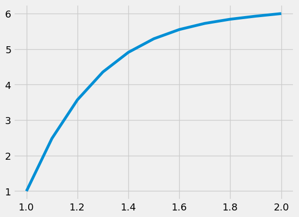

```python
n = 10 # 50  100

# calibration
a = 1
b = 2
alpha = 1
beta = 6
dx = (b-a)/n
P = 3
Q = 2

def f_task2(x):
    return 4 * np.square(x)

# build a container for vector x and y in an array
task2_pre = np.zeros([n+1,2]) # the first column is x, the second column is y
task2_pre[:,0] = [1+i*dx for i in range(0,n+1)]
# set the boundry conditions
task2_pre[0,1] = 1
task2_pre[n,1] = 6

######################
# calculating Matrics
# a_temp, b_temp, c_temp are parameters insider the A_tilde matrix
a_temp = 1 - dx/2*P
b_temp = -2 + dx**2 * Q
c_temp = 1 + dx/2*P

# calculate A_tilde
A_tilde = np.zeros([n-1,n-1])
A_tilde[0,:2] = b_temp , c_temp
A_tilde[n-2, -2:] = a_temp, b_temp
for i in range(1,n-2):
    A_tilde[i,i-1:i+2]=a_temp,b_temp,c_temp

# calculate d_vector
b_vector, c_vector = np.zeros(n-1), np.zeros(n-1)
b_vector = [dx**2 * f_task2(1+i*dx) for i in range(n-1)]
c_vector[0] = alpha * a_temp
c_vector[-1] = beta * c_temp

d_vector = b_vector - c_vector

# solve for x_tilde
A_tilde_inv = np.linalg.inv(A_tilde)
x_tilde = A_tilde_inv.dot(d_vector)
task2_pre[1:-1,1] = x_tilde
plt.plot(task2_pre[:,0], task2_pre[:,1])
```

```python
# Now, write every thing insider a function to finish this question.

def f_task2(x):
    return 4 * np.square(x)

def task2_ploting(n, a=1, b=2, alpha=1, beta=6, P=3, Q=2):
    dx = (b-a)/n

    # build a container for vector x and y in an array
    task2_pre = np.zeros([n+1,2]) # the first column is x, the second column is y
    task2_pre[:,0] = [1+i*dx for i in range(0,n+1)]
    # set the boundry conditions
    task2_pre[0,1] = alpha
    task2_pre[n,1] = beta

    ######################
    # calculating Matrics
    # a_temp, b_temp, c_temp are parameters insider the A_tilde matrix
    a_temp = 1 - dx/2*P
    b_temp = -2 + dx**2 * Q
    c_temp = 1 + dx/2*P

    # calculate A_tilde
    A_tilde = np.zeros([n-1,n-1])
    A_tilde[0,:2] = b_temp , c_temp
    A_tilde[n-2, -2:] = a_temp, b_temp
    for i in range(1,n-2):
        A_tilde[i,i-1:i+2]=a_temp,b_temp,c_temp

    # calculate d_vector
    b_vector = np.zeros(n-1)
    c_vector = np.zeros(n-1)
    b_vector = [dx**2 * f_task2(1+i*dx) for i in range(n-1)]
    c_vector[0] = alpha * a_temp
    c_vector[-1] = beta * c_temp

    d_vector = b_vector - c_vector

    # solve for x_tilde
    A_tilde_inv = np.linalg.inv(A_tilde)
    x_tilde = A_tilde_inv.dot(d_vector)
    task2_pre[1:-1,1] = x_tilde

    return task2_pre
```

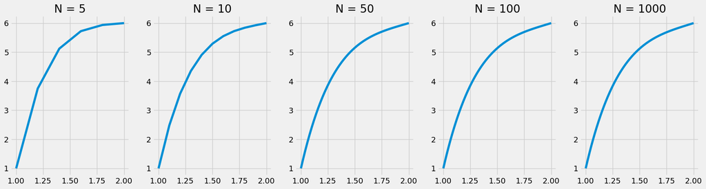

```python
n = [5, 10, 50, 100, 1000]

figure, axes = plt.subplots(1,len(n), figsize=(20,5))
for i,j in enumerate(n):
    temp_task2_plot = task2_ploting(j)
    axes[i].plot( temp_task2_plot[:,0], temp_task2_plot[:,1] )
    axes[i].set_title(f'N = {j}')
plt.show()
```

From the above figure, we can find that the curve is getting smoothier, as the number of steps increase.

Here below are a bit of further proof why the solution is shaped like the above.

If we do not using F.D.M., we solve the O.D.E. instead.

$$y'' + 3y' + 2y = 4x^2$$$$y = c_1 e^{-x} + c_2 e^{-2x} + 2x^2 -6x +7$$

By plug in the boundary condition,

- $y(1) = 1$
- $y(2) = 6$

$$\begin{cases} c_1 e^{-1} + c_2 e^{-2} = -2 \\ c_1 e^{-2} + c_2 e^{-4} = 3 \end{cases}$$

Solve the above equation, and plug $c_1, c_2$ insider of the solution of O.D.E., we can get the exact solution, and exact graph of $y(x)$.

The code and figure is as the following.

Clearly, the result shows that F.D.M. method result converges to the exact solution of O.D.E. as the number of steps increase.

```
[  38.23189732 -118.70318394]
--------------------------------------------------
From the Figure above, we can find that F.D.M. Solution converges to O.D.E. Solution as N growing
```

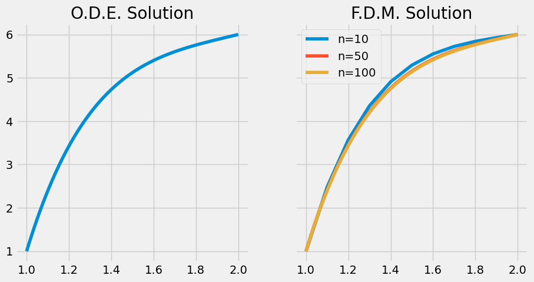

```python
A = np.array( [[np.e**(-1), np.e**(-2)],[np.e**(-2), np.e**(-4)]] )
b = np.array([-2,3]).T
print(np.linalg.inv(A).dot(b))
def y_ode(x):
    return np.linalg.inv(A).dot(b).dot( [np.e**(-x),np.e**(-2*x)] ) \
            + 2 * x**2 - 6 * x + 7

x = np.linspace(1,2,10_000)

print('-'*50)
figure, axes = plt.subplots(1,2, sharey=True, figsize=[10,5])
axes[0].plot(x, y_ode(x))
axes[0].set_title('O.D.E. Solution')
axes[1].plot( task2_ploting(10)[:,0], task2_ploting(10)[:,1] , label='n=10')
axes[1].set_title(f'F.D.M. for N = 10')
axes[1].plot( task2_ploting(50)[:,0], task2_ploting(50)[:,1], label='n=50' )
axes[1].set_title(f'F.D.M. for N = 50')
axes[1].plot( task2_ploting(100)[:,0], task2_ploting(100)[:,1] , label='n=100')
axes[1].set_title(f'F.D.M. Solution')
axes[1].legend()
print('From the Figure above, we can find that F.D.M. Solution converges to O.D.E. Solution as N growing')
```

# Task 3

## Task 3 - i

$$\int_1^3 x^2 dx$$

### The Exact Result is:

$$\frac{1}{3}x^3 \ \bigg|^3_1 = \frac{26}{3}\approx 8.6667$$

### Monte Carlo Integration / Simulation Result:

Let $y=\frac{x-1}{2}$, then

- $y$ is gauge to be $y\in (0,1)$
- $2dy = dx$
- $x = 2y+1$.

Thus,

$$\int_1^3 x^2 dx \to \int_0^1 (2y+1)^2 2 dy$$$$ \int_0^1 (2y+1)^2 2 dy $$$$\Leftrightarrow \mathbb{E}(8U^2+8U+2)$$

, where $U\sim U(0,1)$, a union-form distribution between 0 and 1.

## Task 3 -ii

$$\int_0^{\infty} exp(-x^2) dx$$

### The Exact Result is:

As we know $\phi(x) = \frac{1}{\sqrt{2\pi}}e^{-x^2} \sim N(0,1)$ has a cumulative density function in $\mathbb{R}$ of 1. $$\int_{-\infty}^{\infty} \phi(x)dx=1$$

### Monte Carlo Integration / Simulation Result:

Let $y=\frac{1}{1+x}$, then

- $x\in (0,+\infty)$ is gauge to be $y \in (1,0)$.
- $dy = -\frac{1}{(1+x)^2} dx = -y^2 dx$, so $dx = - \frac{1}{y^2} dy$
- $x=\frac{1}{y}-1$

Thus,

$$\int_0^{\infty} exp(-x^2) dx$$

$$ = \int_1^0 exp\big(-(\frac{1}{y}-1)^2 \big) (-1) \frac{1}{y^2} dy$$$$ = \int_0^1 exp\big(-(\frac{1}{y}-1)^2 \big) \frac{1}{y^2} dy$$$$\Leftrightarrow \mathbb{E}\bigg(exp\big(-(\frac{1}{U}-1)^2 \big) \frac{1}{U^2}\bigg)$$

, where $U\sim U(0,1)$, a union-form distribution between 0 and 1.

## Task3 - iii

$$\frac{1}{\sqrt{2\pi}}\int_{-\infty}^{\infty}x^4 exp(-\frac{x^2}{2}) dx$$

### The Exac Solution is:

$$\frac{1}{\sqrt{2\pi}}\int_{-\infty}^{\infty}x^4 exp(-\frac{x^2}{2}) dx = 3$$

The proof is as the following,

$$\frac{1}{\sqrt{2\pi}}\int_{-\infty}^{\infty}x^4 exp(-\frac{x^2}{2}) dx $$$$=\frac{1}{\sqrt{2\pi}}\int_{-\infty}^{\infty} x^3 d(e^{-x^2/2})$$

, by partial integral,

$$ =\frac{1}{\sqrt{2\pi}}e^{-x^2/2}x^3 \bigg|_{-\infty}^{+\infty}-\frac{1}{\sqrt{2\pi}}\int_{-\infty}^{\infty} e^{-x^2/2} d(x^3)$$

, the first term is zero, as $e^{-x^2}$ is in higher order of converging to infity. That fact can also eaily be proved by L'Hospital rule.

$$=-\frac{3}{\sqrt{2\pi}}\int_{-\infty}^{\infty} e^{-x^2/2}x^2 dx =\frac{3}{\sqrt{2\pi}}\int_{-\infty}^{\infty} e^{-x^2/2}x d(-x^2/2) $$$$ =-\frac{3}{\sqrt{2\pi}}\int_{-\infty}^{\infty} x d(e^{-x^2/2}) $$

, by partial intergral, and then the first term disappear as well, we can get,

$$ =\frac{3}{\sqrt{2\pi}}\int_{-\infty}^{\infty} e^{-x^2/2} dx $$$$=\frac{3}{\sqrt{2\pi}} 2\times \int_{0}^{\infty} e^{-x^2/2} dx $$$$=\frac{3}{\sqrt{2\pi}} 2\times \frac{\sqrt{2\pi}}{2}=3$$

### Monte Carlo Integral / Simulation result is:

$$\frac{1}{\sqrt{2\pi}}\int_{-\infty}^{0}x^4 exp(-\frac{x^2}{2}) dx + \frac{1}{\sqrt{2\pi}}\int_{0}^{\infty}x^4 exp(-\frac{x^2}{2}) dx$$

Since, both $x^4$ and $\phi(x)$ are symmetric, we can double the above function to be,

$$2\times \frac{1}{\sqrt{2\pi}}\int_{0}^{\infty}x^4 exp(-\frac{x^2}{2}) dx $$

Let $y=\frac{1}{1+x}$, then

- $x\in (0,\infty)$ is gauge to be $y \in (1,0)$
- $dy = -\frac{1}{(1+x)^2} dx = -y^2 dx$, so $dx = - \frac{1}{y^2} dy$
- $x=\frac{1}{y}-1$

Thus,

```python
task3_pre = pd.DataFrame(np.zeros([2,3]),
                         columns=['function_1', 'function_2','function_3'],
                         index = ['Exact_Sol','Sim_Sol'])

def f1(x):
    return 8 * np.square(x) +  8 * x + 2

def f2(x):
    return np.exp(- np.square(1/x - 1)) * 1 / np.square(x)

def f3(x):
    part1 = np.square(np.square( 1/x - 1 ))
    part2 = np.exp( -0.5 * np.square(1/x - 1) )
    part3 = np.square(1/x)
    return np.sqrt(2/np.pi) * part1 * part2 * part3
```

```python
# number of random variable ~ U(0,1)
N = 1_000_000

# np.random.seed(0)
U = np.random.rand(N)

# function 1
sim_result_1 = np.mean( f1(U) )
exact_result_1 = 8.6667
task3_pre.function_1['Exact_Sol'] = exact_result_1
task3_pre.function_1['Sim_Sol'] = sim_result_1

# function 2
sim_result_2 = np.mean( f2(U) )
exact_result_2 = np.sqrt(np.pi)/2
task3_pre.function_2['Exact_Sol'] = exact_result_2
task3_pre.function_2['Sim_Sol'] = sim_result_2

# function 3
sim_result_3 = np.mean( f3(U) )
exact_result_3 = 3
task3_pre.function_3['Exact_Sol'] = exact_result_3
task3_pre.function_3['Sim_Sol'] = sim_result_3

task3_pre
```

|  | function_1 | function_2 | function_3 |
| --- | --- | --- | --- |
| Exact_Sol | 8.666700 | 0.886227 | 3.000000 |
| Sim_Sol | 8.668247 | 0.885711 | 3.002424 |

With the number of random variables be 1 million: From the above table, we can find that for the integral (i), (ii), and (iii), the Monte Carlo Integral solution is all close to the Exact Solution of the integral, as we have proved before.

## Error & the Number of Random Variable

Now, let's see how the error, which we define as the difference between Monte Carlo result and the Exact result, evoloves with the number of random variables increase.

```python
# set the number of random variables, by giving starting/ending points and interval.
start = 100
end = 100_000
interval = 100
difference = np.zeros([len(range(start, end, interval)), 3])

j=0
for i in range(start, end, interval):
    U = np.random.rand(i)
    sim_result_1 = np.mean( f1(U) )
    exact_result_1 = 8.6667
    difference[j][0] = sim_result_1 - exact_result_1

    sim_result_2 = np.mean( f2(U) )
    exact_result_2 = np.sqrt(np.pi)/2
    difference[j][1] = sim_result_2 - exact_result_2

    sim_result_3 = np.mean( f3(U) )
    exact_result_3 = 3.0
    difference[j][2] = sim_result_3 - exact_result_3

    j+=1
```

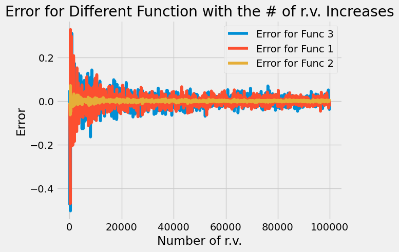

```
From the Figure above, we can find that the error converges to zero, as the number of random variables increases.
```

```python
xlim = [i for i in range(start, end, interval)]
plt.plot(xlim, difference[:,2], label = 'Error for Func 3')
plt.plot(xlim, difference[:,0], label = 'Error for Func 1')
plt.plot(xlim, difference[:,1], label = 'Error for Func 2')
plt.legend()
plt.title('Error for Different Function with the # of r.v. Increases')
plt.xlabel('Number of r.v.')
plt.ylabel('Error')
plt.show()

print('From the Figure above, we can find that the error converges to zero, as the number of random variables increases.')
```